# Exploratory Data Analysis

## Step 0: Import the files

We import the files train.csv and test.csv, put them together to make sure they have the same levels. We will pre-process the data on the full dataset to simplify this analysis.

```r
full <- rbind(fread("train.csv",
                    stringsAsFactors = FALSE,
                    data.table = FALSE),
              fread("test.csv",
                    stringsAsFactors = FALSE,
                    data.table = FALSE) %>%
                mutate(SalePrice = as.numeric(NA))) %>%
  mutate_if(is.character,function(x){factor(x)}) %>%
  mutate_if(is.integer,function(x){as.numeric(x)})
```

We keep the Id column for now, but it will be removed later on.

## Step 1: Exploring the Output column

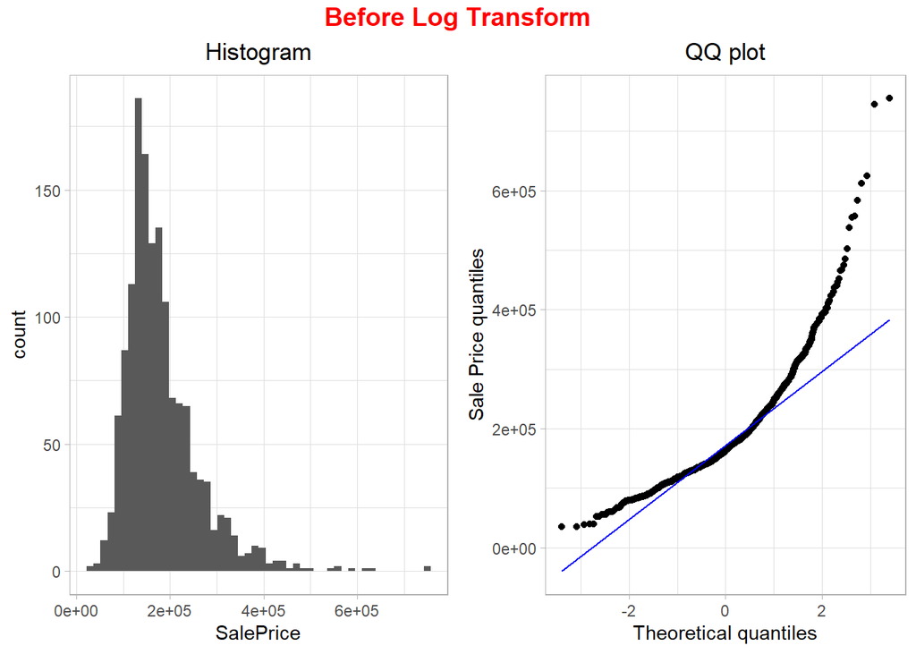

We can see that the SalePrice column has a right tail. We will log the predictions to have a normal distributed target.

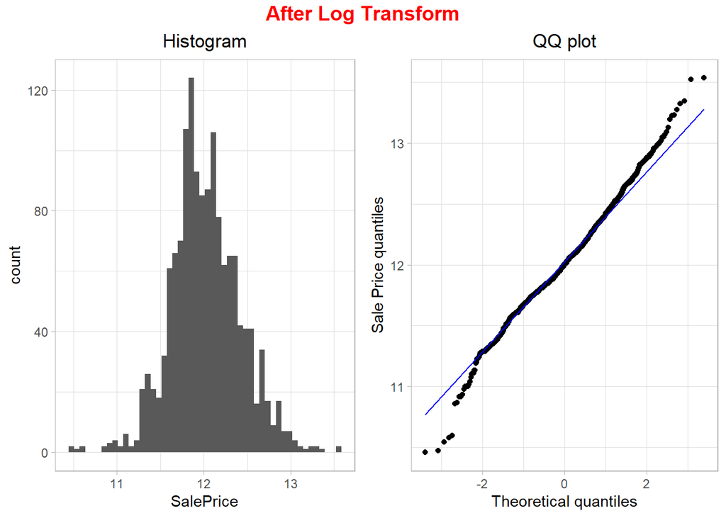

We see that 5 sales have very low SalePrices and 2 very high ones.

After short investigation, we can see that the 5 houses with low SalePrice are very old houses (built before 1950) of below average general condition and usually with an abnormal sale condition.

As for the 2 rows with very high SalePrice, they were built around 1994-6, with overall excellent condition for each check done (Garages, rooms, Kitchen, etc). One even has a pool.

We do not consider these 7 profiles as outliers, and will keep them in the analysis.

## Step 2: Missing values

Let’s first look at the columns with missing values:

```r
missing_cols <- full %>%
  apply(MARGIN = 2,
        function(x){sum(is.na(x))}) %>%
  as.matrix() %>%
  as.data.frame() %>%
  rownames_to_column() %>%
  filter(V1 > 0) %>%
  arrange(-V1)

missing_cols
```

```
##         rowname   V1
## 1        PoolQC 2909
## 2   MiscFeature 2814
## 3         Alley 2721
## 4         Fence 2348
## 5     SalePrice 1459
## 6   FireplaceQu 1420
## 7   LotFrontage  486
## 8   GarageYrBlt  159
## 9  GarageFinish  159
## 10   GarageQual  159
## 11   GarageCond  159
## 12   GarageType  157
## 13     BsmtCond   82
## 14 BsmtExposure   82
```

[output cut: 21 more lines]

Let’s look at each of these predictors with missing variable, group by group, to try to understand the best way to fill them.

### Pool variables

PoolQC is pool quality, where NA means in theory “no pool”. It is an ordered factor with 99.6574% of NAs. It is an ordered variable.

There is another variable called PoolArea, for the area of the pool. When we look at the area if there is a pool or not, we see that the area is most of the time 0 if there is no pool.

```r
table(full$PoolArea,is.na(full$PoolQC))
```

```
##
##       FALSE TRUE
##   0       0 2906
##   144     1    0
##   228     1    0
##   368     0    1
##   444     0    1
##   480     1    0
##   512     1    0
##   519     1    0
##   555     1    0
##   561     0    1
##   576     1    0
##   648     1    0
##   738     1    0
##   800     1    0
```

We will add “No” as a level, and replace all NAs that have 0 as area by “No”. the NAs with PoolArea>0 will be filled based on the Overall quality of the house:

- if OverallQual is <= 2, returns “Po”
- else, if OverallQual is <= 4, returns “Fa”
- else, if OverallQual is <= 6, returns “TA”
- else, if OverallQual is <= 8, returns “Gd”
- else, returns “Ex”

### MiscFeature variable

If we look at the variable MiscFeature, we see that 96.4029% of the values are missing. It is an unordered factor.

```r
table(is.na(full$MiscFeature))
```

```
##
## FALSE  TRUE
##   105  2814
```

When looking at the boxplots we see that when there are values, the impact on the sold price is quite significant.

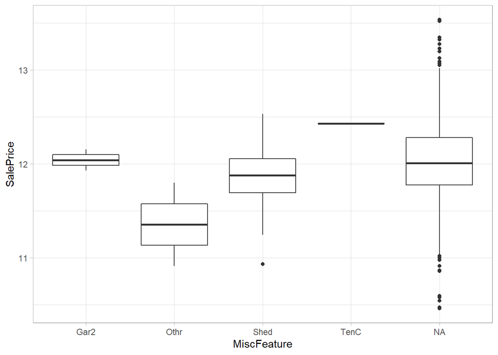

We are replacing the missing Misc features by “No”.

### Alley variable

The Alley contains the type of alley to the house, where a missing value means that there is not any alley. 93.2169% of the values are missing. It is an unordered factor.

```r
table(is.na(full$Alley))
```

```
##
## FALSE  TRUE
##   198  2721
```

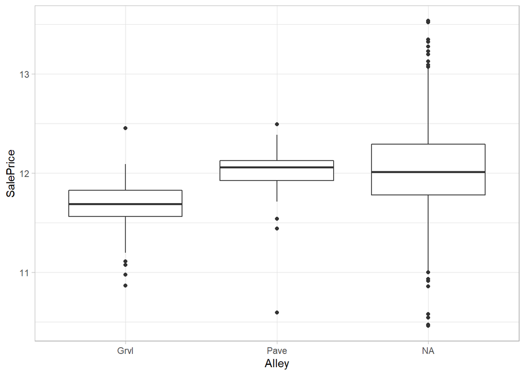

We replace the NA by “No”.

### Fence variable

The Fence contains the type of fence around the house, where a missing value means that there is not any fence 80.4385% of the values are missing. It is unordered.

```r
table(is.na(full$Fence))
```

```
##
## FALSE  TRUE
##   571  2348
```

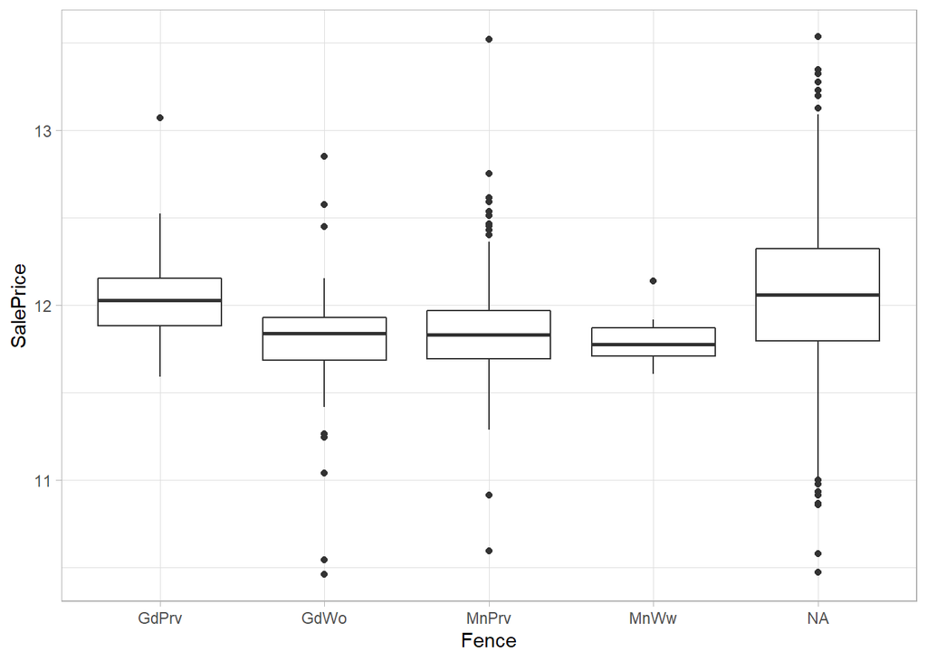

We replace the NA by “No”.

### Fireplace variables

There are 2 variables relative to the fireplaces: Fireplaces, counting the number of fireplaces, and FireplaceQu for the fireplace quality.

48.6468% of the FireplaceQu values are missing, which correspond as seen below to the houses without any fireplaces. It is an ordered variable.

```r
table(full$Fireplaces, is.na(full$FireplaceQu))
```

```
##
##     FALSE TRUE
##   0     0 1420
##   1  1268    0
##   2   219    0
##   3    11    0
##   4     1    0
```

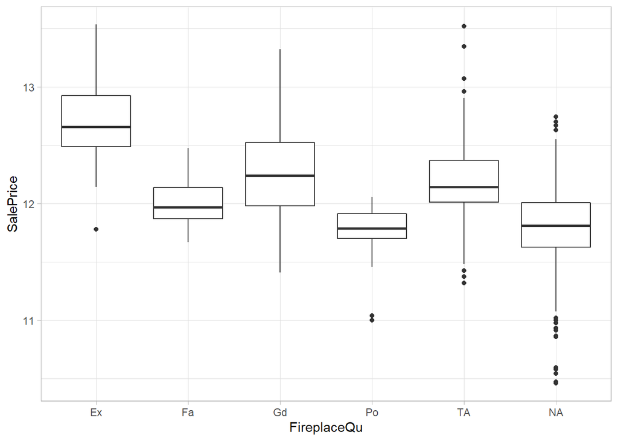

We replace the NA by “No”.

### LotFrontage variable

The LotFrontage variable contains the linear feet of street connected to property. It is a numerical variable, with 16.6495% missing values.

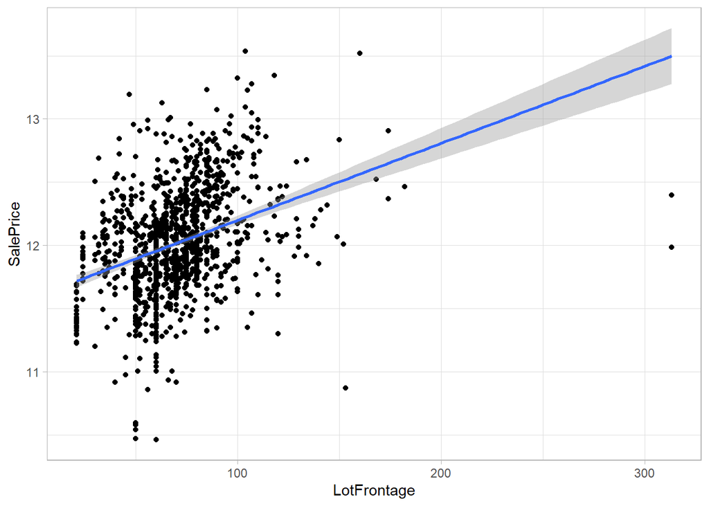

We fill the variable with a knn model.

### Garage variables

There are 7 variables related to houses’ garages.

GarageCars and GarageArea have 1 missing value for the observation Id 2577. This house seems to not have any garage, thus we replace the values of these 2 predictors by 0 and remove the value in GarageType.

```r
full[2577,] %>% data.frame()
```

```
##     Id MSSubClass MSZoning LotFrontage LotArea Street Alley LotShape
## 1 2577         70       RM          50    9060   Pave  <NA>      Reg
##   LandContour Utilities LotConfig LandSlope Neighborhood Condition1 Condition2
## 1         Lvl    AllPub    Inside       Gtl       IDOTRR       Norm       Norm
##   BldgType HouseStyle OverallQual OverallCond YearBuilt YearRemodAdd RoofStyle
## 1     1Fam     2Story           5           6      1923         1999     Gable
##   RoofMatl Exterior1st Exterior2nd MasVnrType MasVnrArea ExterQual ExterCond
## 1  CompShg     Wd Sdng     Plywood       None          0        TA        TA
##   Foundation BsmtQual BsmtCond BsmtExposure BsmtFinType1 BsmtFinSF1
## 1     BrkTil       Gd       TA           No          ALQ        548
##   BsmtFinType2 BsmtFinSF2 BsmtUnfSF TotalBsmtSF Heating HeatingQC CentralAir
## 1          Unf          0       311         859    GasA        Ex          Y
##   Electrical X1stFlrSF X2ndFlrSF LowQualFinSF GrLivArea BsmtFullBath
## 1      SBrkr       942       886            0      1828            0
##   BsmtHalfBath FullBath HalfBath BedroomAbvGr KitchenAbvGr KitchenQual
## 1            0        2        0            3            1          Gd
##   TotRmsAbvGrd Functional Fireplaces FireplaceQu GarageType GarageYrBlt
## 1            6        Typ          0        <NA>     Detchd          NA
##   GarageFinish GarageCars GarageArea GarageQual GarageCond PavedDrive
## 1         <NA>         NA         NA       <NA>       <NA>          Y
##   WoodDeckSF OpenPorchSF EnclosedPorch X3SsnPorch ScreenPorch PoolArea PoolQC
## 1        174           0           212          0           0        0   <NA>
##   Fence MiscFeature MiscVal MoSold YrSold SaleType SaleCondition SalePrice
## 1 MnPrv        <NA>       0      3   2007       WD        Alloca        NA
```

In the 5.4128% of the rows when there is no garage, GarageCars and GarageArea are fixed to 0 and GarageType, GarageYrBlt, GarageFinish, GarageQual and GarageCond are missing. All 5 are ordered factors.

There is a row with Id 2127 where GarageYrBlt, GarageFinish, GarageQual and GarageCond are missing, but GarageArea > 0 and GarageType exists.

Except for this row, the predictors GarageType, GarageFinish, GarageQual and GarageCond will be filled with a new value “No” and GarageYrBlt will be filled by the year the house was built.

We will fill the row 2127 with a knn method.

### Basement variables

There are 11 variables related to houses’ basements, and all of them have missing values with different percentages:

- There are 2.8092% missing values for BsmtCond and BsmtExposure,
- There are 2.7749% missing values for BsmtQual,
- There are 2.7407% missing values for BsmtFinType2,
- There are 2.7064% missing values for BsmtFinType1,
- There are 0.0685% missing values for BsmtFullBath and BsmtHalfBath,
- There are 0.0343% missing values for BsmtFinSF1, BsmtFinSF2, BsmtUnfSF and TotalBsmtSF

All of these predictors are either ordered factors or numerical.

The row with Id 2121 is NA for all basement variables. We replace the numerical values by 0 and the factor ones by “No”.

The row with Id 2189 is the other one with NA for the variables related to Bathrooms in the basement. We replace them with 0.

The rows with Id 2041, 2186 and 2525 contain missing values only for BsmtCond. We replace them with the values in BsmtQual, which are average.

The rows with Id 949, 1488 and 2349 contain missing values only for BsmtExposure. Since for these profiles the BsmtQual and BsmtCond are average, we replace them with the “Av” value.

All other rows, we consider that there is no basement. We replace the missing value by “No” except for BsmtExposure where we will replace it with “None” since the value “No” already exists.

### Masonry veneer variables

There are 2 variables related to Masonry veneer: MasVnrArea and MasVnrType. The first has 23 missing values, and the latter 24.

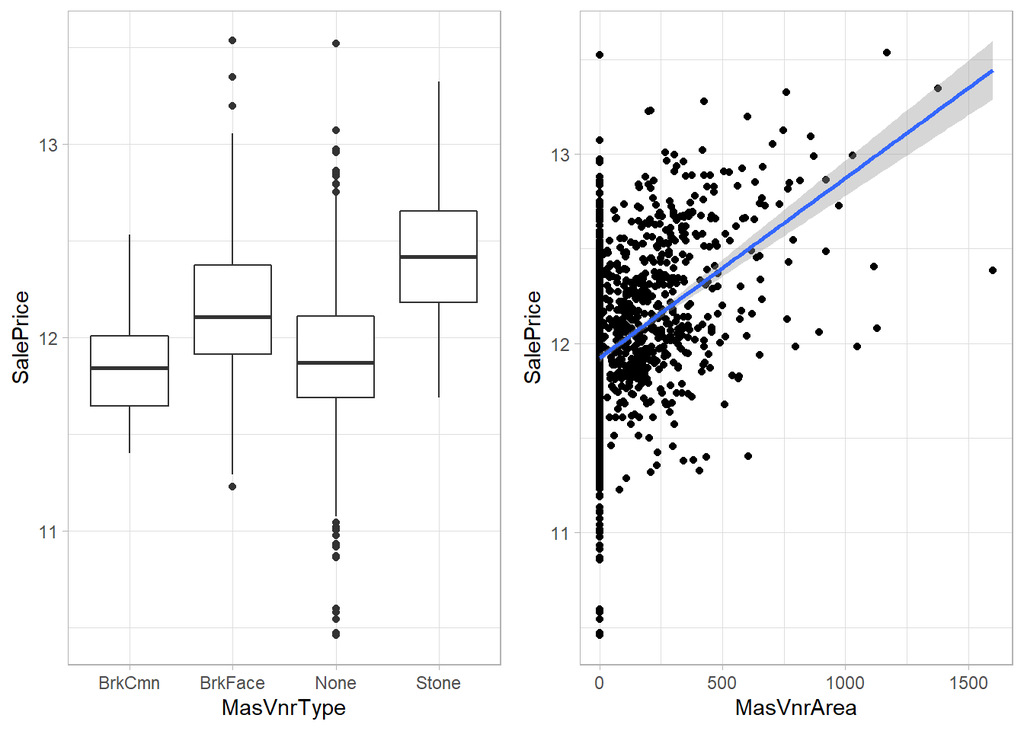

Row Id 2611 has a missing value for MasVnrType but not MasVnrArea. We will fill MasVnrArea with 0 and MasVnrType with “None” for all missing values except Id 2611, and use a knn impute for this specific row.

### Other variables

MSZoning has 4 missing values, Utilities 2, Functional 2, Exterior1st, Exterior2nd, Electrical, KitchenQual and SaleType have 1. All of these are factors, some ordered some not.

We fill these variables with a knn impute.

## Step 3: Change variable types

Some of the columns received the wrong type when reading the files: either they are written as categorical but should be numerical (and ordered), or they are numerical but should have been categoricals.

### Categoricals to Numericals

Most of the factors (MSZoning, Street, LandContour, …) are unordered factors and be kept as factors.

LotShape is a categorical variable containing the general shape of the property. It is ordered, and “Reg” is the highest value. We replace the value with Reg = 0, IR1 = 1, IR2 = 2 and IR3 = 3.

```r
table(full$LotShape)
```

```
##
##  IR1  IR2  IR3  Reg
##  968   76   16 1859
```

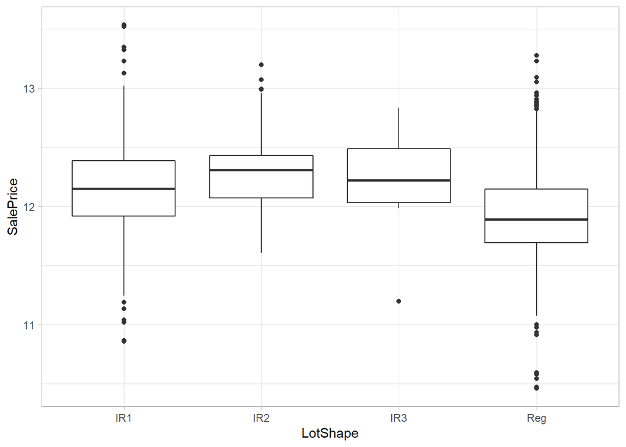

LandSlope is a categorical variable containing the slope of the property. It is ordered, and the levels are currently ordered correctly, thus we will translate the factor into the order of the levels.

```r
table(full$LandSlope)
```

```
##
##  Gtl  Mod  Sev
## 2778  125   16
```

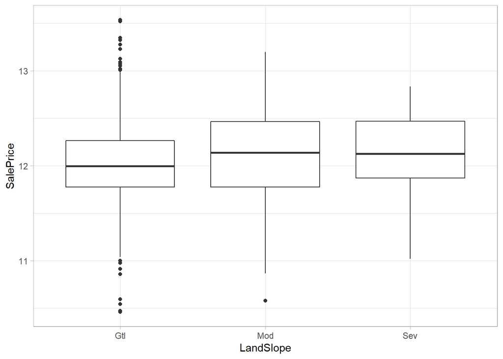

ExterQual, ExterCond, BsmtQual, BsmtCond, HeatingQC, KitchenQual, FireplaceQu, GarageQual, GarageCond, PoolQC are all ordered variables with the same ordered levels: Ex, Gd, TA, Fa, Po, No. We re-order all the levels to be in this order, and then translate these factors into the order of the levels (aka Ex = 0, Gd = 1, …)

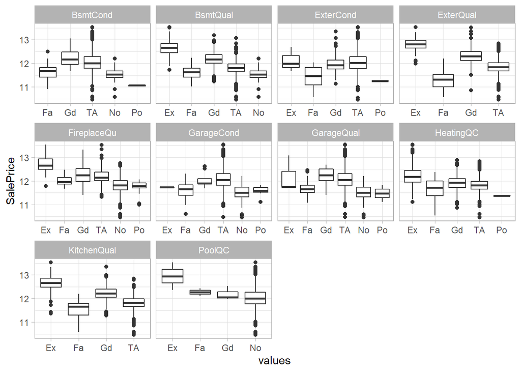

BsmtExposure is an ordered variable with slightly different levels than the ones we worked on just before. We re-order the levels in the order Gd - Av - Mn - No - None.

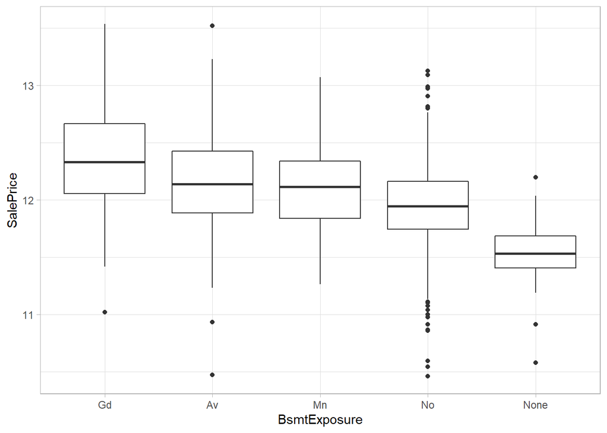

BsmtFinType1 and BsmtFinType2 are 2 ordered variables with specific levels. We re-order the levels in the order: GLQ, ALQ, BLQ, Rec, LwQ, Unf, No.

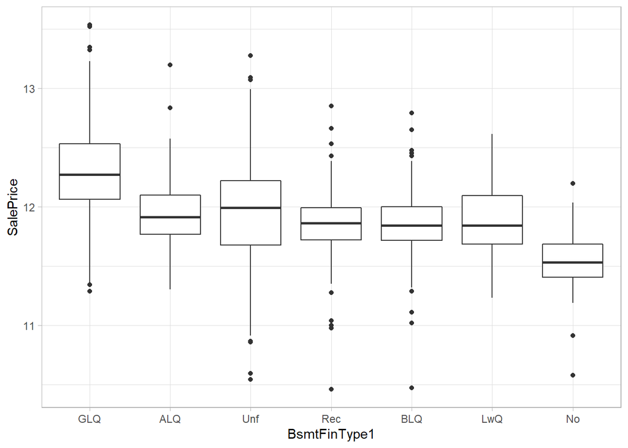

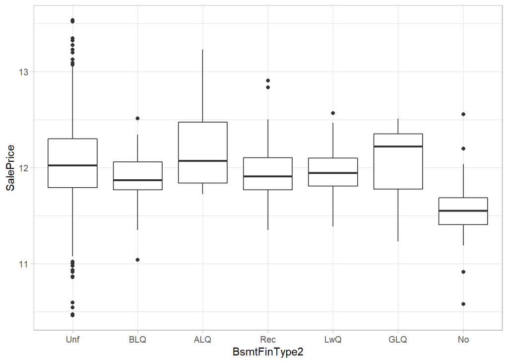

Functional is an ordered variable containing the home functionality.

```r
table(full$Functional)
```

```
##
## Maj1 Maj2 Min1 Min2  Mod  Sev  Typ
##   19    9   65   70   35    2 2719
```

Due to the low volume in the different categories, we bin them together:

- “Typ” will contain the typical functionality
- “Min” will contain deductions from minor to moderate
- “Maj” will contain major / sever damages.

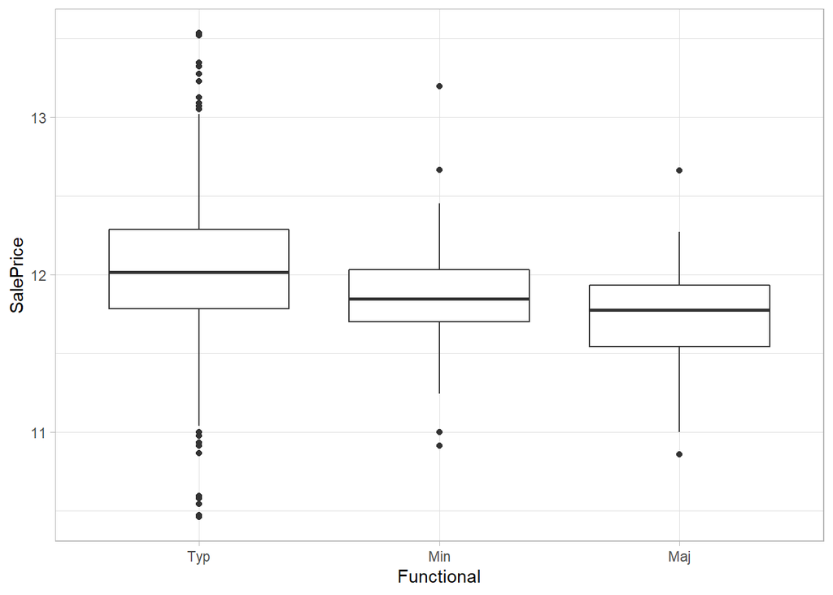

GarageFinish is an ordered variable containing the interior finish of the garage(s). We re-organise the levels to have No = 0, Unf = 1, RFn = 2, Fin = 3.

```r
table(full$GarageFinish)
```

```
##
##  RFn  Unf  Fin   No
##  811 1231  719  158
```

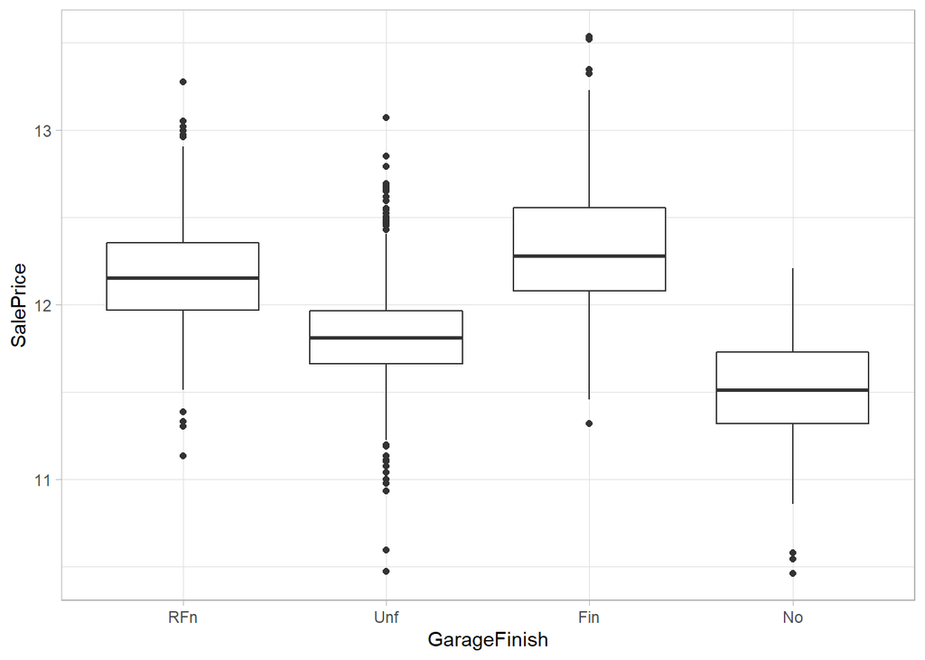

PavedDrive is an ordered variable containing the definition of how paved is the driveway. We re-organise the levels to have “N” = 0, “P” = 1, “Y” = 2.

```r
table(full$PavedDrive)
```

```
##
##    N    P    Y
##  216   62 2641
```

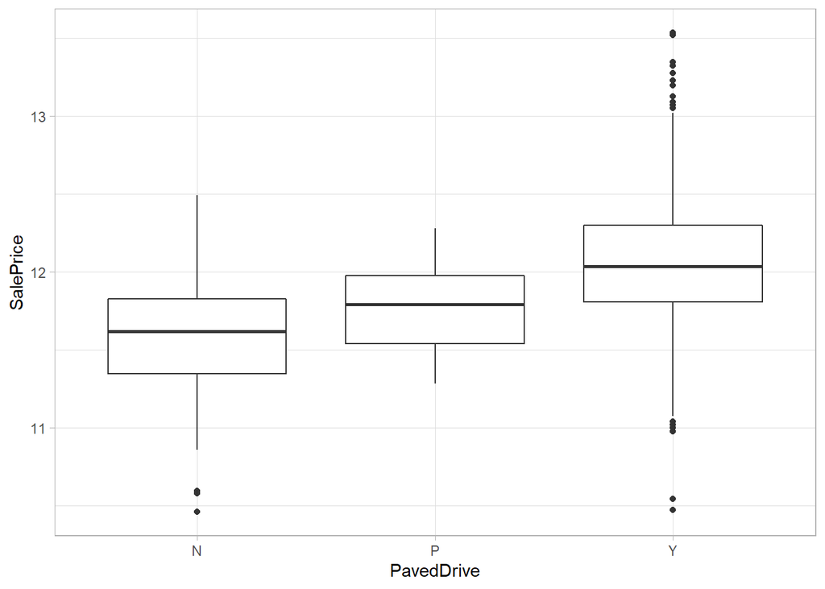

### Numericals to Categoricals

Some of the columns that are numerical could be seen as factors instead:

MSSubClass identifies the type of dwelling involved in the sale. It is coded as a numerical variable but is really categorical.

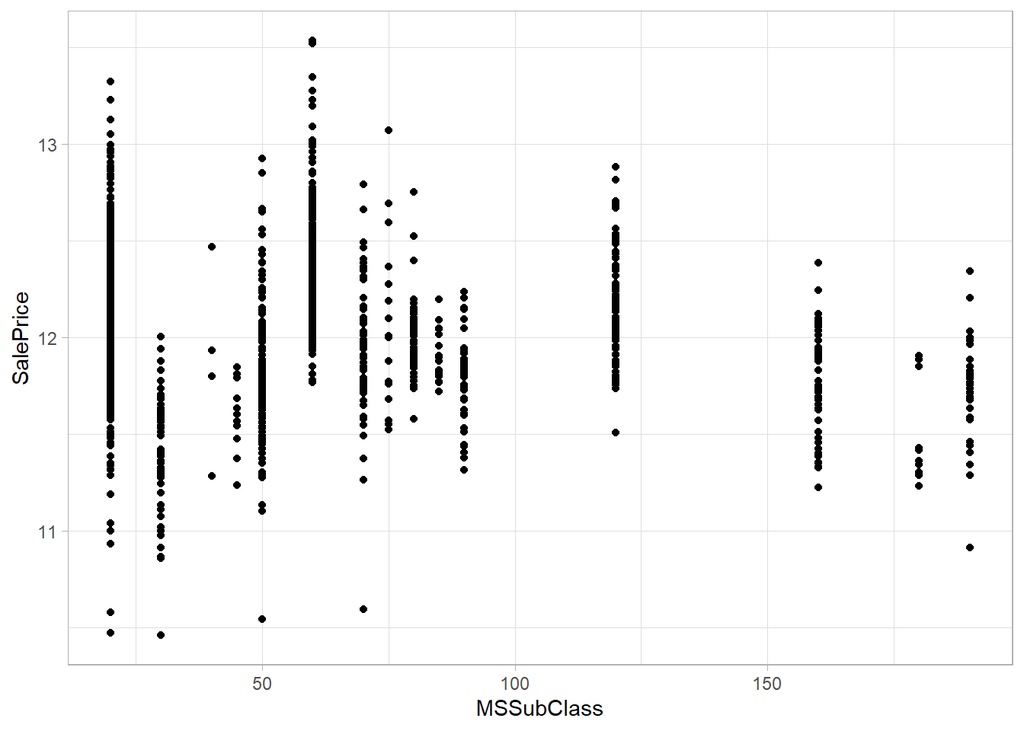

MoSold and YrSold give details about the date when the house was sold.

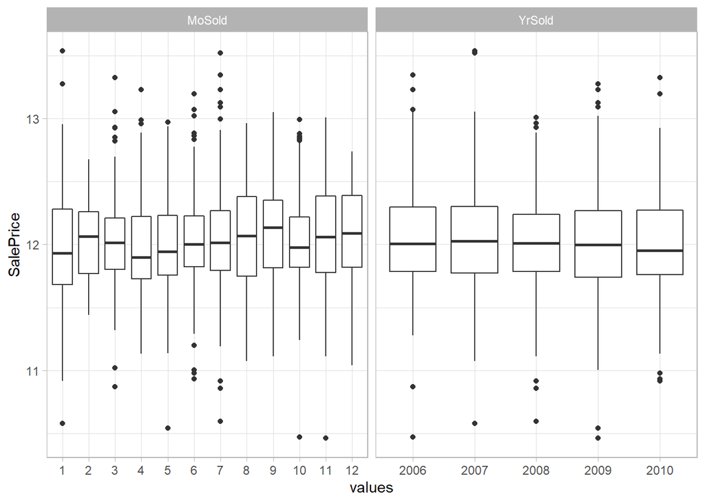

We correct these 3 variables to categoricals.

## Step 4: Feature engineering

Let’s group some of the variables together to see if they have a better impact on the SalePrice

### 4.1 Total number of bathrooms

Let’s group them together into a TotalBathrooms variable

```r
myrecipe <- myrecipe %>%
  step_mutate(TotalBathrooms = BsmtFullBath + FullBath + 0.5 * ( BsmtHalfBath +HalfBath) )
```

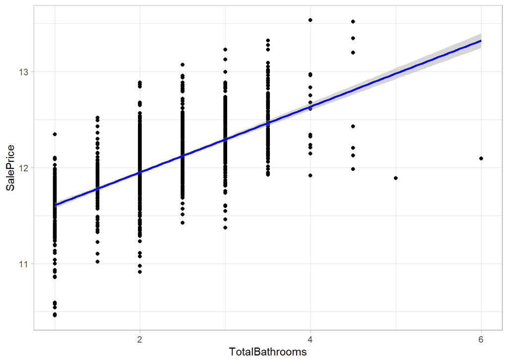

### 4.2 House age, remodeled (y/n) and IsNew

```r
myrecipe <- myrecipe %>%
  step_mutate(Age = as.numeric(as.character(YrSold)) - YearBuilt,
              Remodeled = factor(case_when(YearRemodAdd == YearBuilt ~ "Y",
                                           TRUE ~ "N")),
              New = factor(case_when(Age < 2 ~ "Y",
                                     TRUE ~ "N")))
```

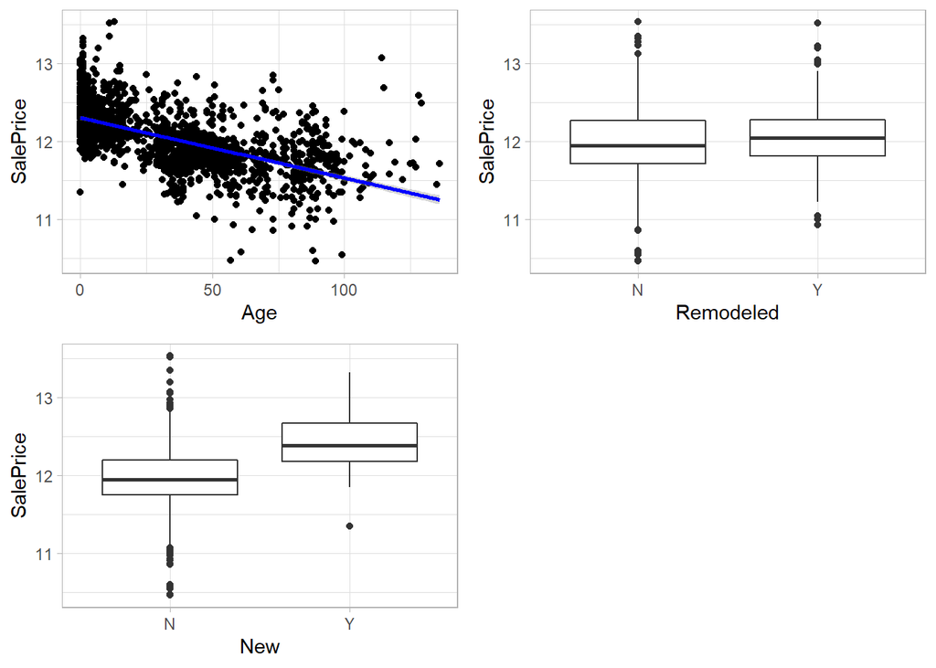

### 4.3 Total Square feet

Let’s group all the housing area and the porch area.

```r
myrecipe <- myrecipe %>%
  step_mutate(PorchArea = WoodDeckSF + OpenPorchSF + EnclosedPorch + `3SsnPorch` + ScreenPorch,
              TotalSquareFeet = GrLivArea + GarageArea + BsmtFinSF1 + BsmtFinSF2 + LowQualFinSF)
```

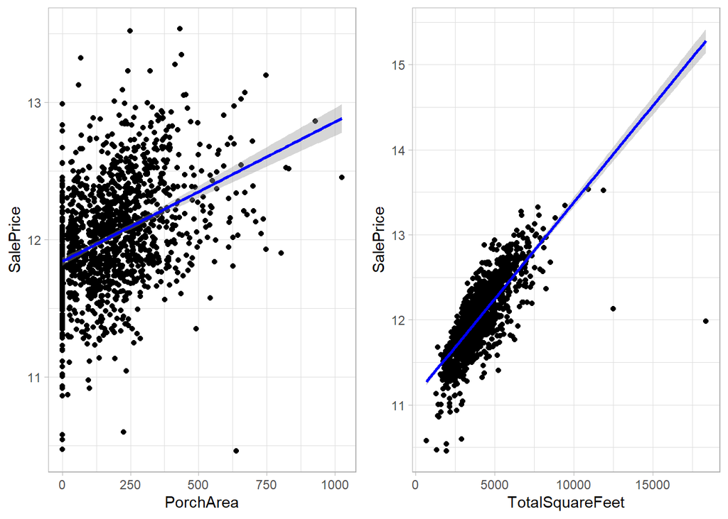

### 4.4 Bin categories that have large number of categories:

When looking at the categorical variables, we see that some of them have a large number of categories, with small number of rows in each:

```r
sapply(full %>%
         dplyr::select(Neighborhood,
                       MSSubClass,
                       Exterior1st,
                       Exterior2nd),
       table)
```

```
## $Neighborhood
##
## Blmngtn Blueste  BrDale BrkSide ClearCr CollgCr Crawfor Edwards Gilbert  IDOTRR
##      28      10      30     108      44     267     103     194     165      93
## MeadowV Mitchel   NAmes NoRidge NPkVill NridgHt  NWAmes OldTown  Sawyer SawyerW
##      37     114     443      71      23     166     131     239     151     125
## Somerst StoneBr   SWISU  Timber Veenker
##     182      51      48      72      24
##
## $MSSubClass
##
##   60   20   70   50  190   45   90  120   30   85   80  160   75  180   40  150
##  575 1079  128  287   61   18  109  182  139   48  118  128   23   17    6    1
##
## $Exterior1st
##
## AsbShng AsphShn BrkComm BrkFace  CBlock CemntBd HdBoard ImStucc MetalSd Plywood
##      44       2       6      87       2     126     442       1     450     221
##   Stone  Stucco VinylSd Wd Sdng WdShing
##       2      43    1026     411      56
##
## $Exterior2nd
##
## AsbShng AsphShn Brk Cmn BrkFace  CBlock CmentBd HdBoard ImStucc MetalSd   Other
##      38       4      22      47       3     126     406      15     447       1
## Plywood   Stone  Stucco VinylSd Wd Sdng Wd Shng
##     270       6      47    1015     391      81
```

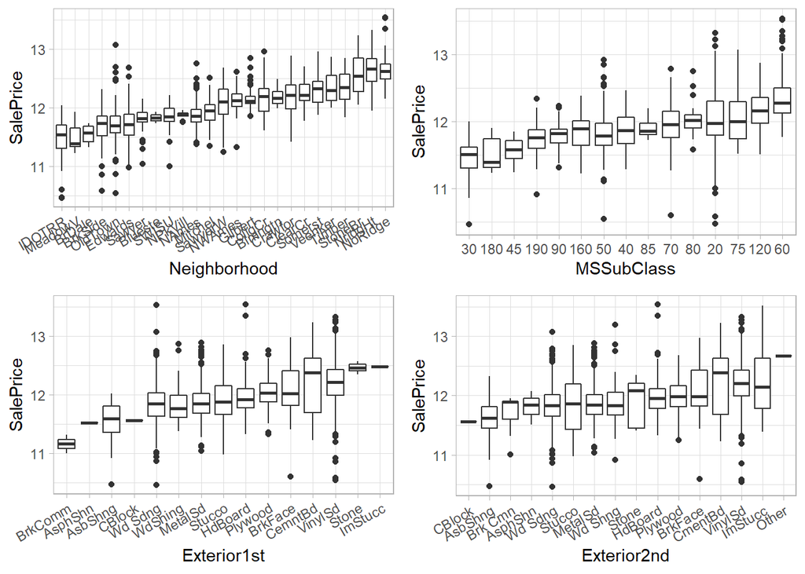

```r
myrecipe <- myrecipe %>%
  step_mutate(BinNeigh = case_when(Neighborhood %in% c("MeadowV","IDOTRR","BrDale") ~ "Low",
                                   Neighborhood %in% c("StoneBr","NoRidge","NridgHt") ~ "High",
                                   TRUE ~ "Med" ),
              BinMSSub = case_when(MSSubClass %in% c("180","30","45") ~ "Low",
                                   MSSubClass %in% c("120","60") ~ "High",
                                   TRUE ~ "Med" ),
              BinExt1 = case_when(Exterior1st %in% c("AsbShng","AsphShn",
                                                     "CBlock","BrkComm") ~ "Low",
                                  Exterior1st %in% c("VinylSd","CemntBd",
                                                     "Stone","ImStucc") ~ "High",
                                  TRUE ~ "Med" ),
              BinExt2 = case_when(Exterior2nd %in% c("CBlock","AsbShng") ~ "Low",
                                  Exterior2nd %in% c("VinylSd","CemntBd",
                                                     "ImStucc","Other") ~ "High",
                                  TRUE ~ "Med" ) )
```

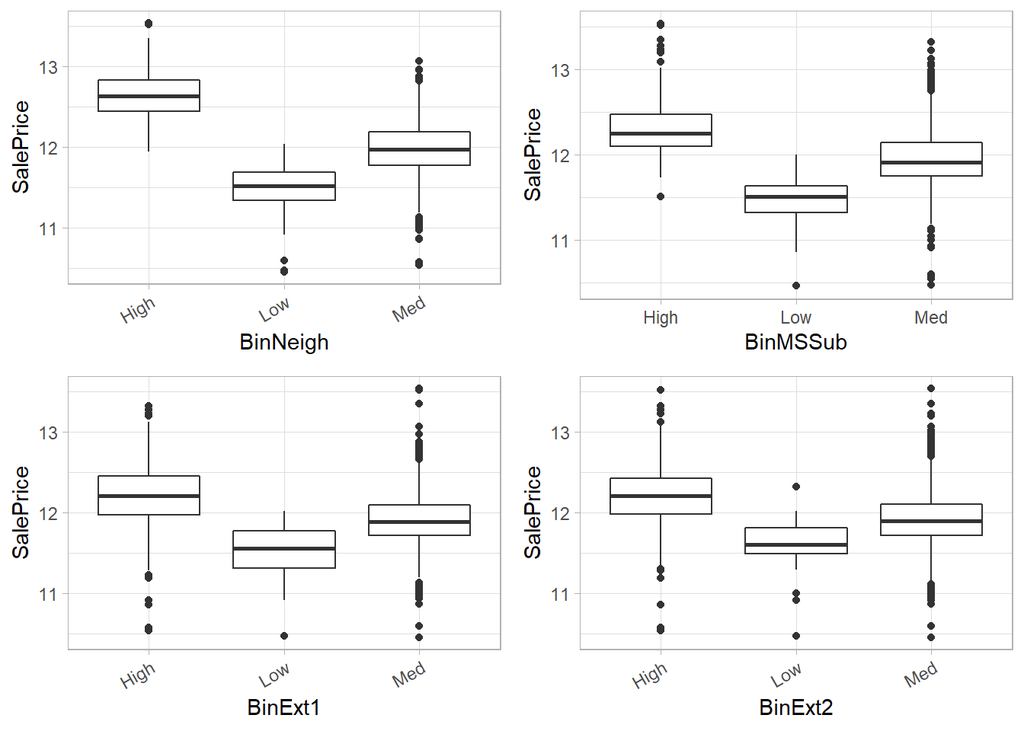

### 4.5 Center and Scale the numerical values

We center and Scale the numerical values, except the output. It will help with the columns with outliers

```r
myrecipe <- myrecipe  %>%
  step_center(all_numeric(), - all_outcomes()) %>% # to standardize the dataset
  step_scale(all_numeric(), -all_outcomes())


full <- test_recipe(myrecipe)
```

### 4.6 ‘Other’ level

In some factors, when there are categories with a low volume of data ( < 10%), we can create a new category called “Other”.

We are not updating the factors we already worked on above in this section 4.

```r
full %>%
  select_if(is.factor) %>%
  dplyr::select(-MSSubClass, - Remodeled, -New,
                - Neighborhood, -Exterior1st, -Exterior2nd,
                -BinNeigh, -BinMSSub, -BinExt1, -BinExt2) %>%
  select_if(function(x){
    sum( table(x) < nrow(full) * 0.1) > 1 & length(table(x))>2 }) %>%
  map(table)
```

```
## $MSZoning
##
## C (all)      FV      RH      RL      RM
##      25     139      26    2268     461
##
## $Alley
##
## Grvl Pave   No
##  120   78 2721
##
## $LotShape
##
##  Reg  IR1  IR2  IR3
## 1859  968   76   16
##
## $LandContour
##
##  Bnk  HLS  Low  Lvl
##  117  120   60 2622
##
## $LotConfig
##
##  Corner CulDSac     FR2     FR3  Inside
##     511     176      85      14    2133
##
## $LandSlope
##
##  Gtl  Mod  Sev
## 2778  125   16
##
## $Condition1
##
## Artery  Feedr   Norm   PosA   PosN   RRAe   RRAn   RRNe   RRNn
##     92    164   2511     20     39     28     50      6      9
##
## $Condition2
##
## Artery  Feedr   Norm   PosA   PosN   RRAe   RRAn   RRNn
##      5     13   2889      4      4      1      1      2
##
```

[output cut: 84 more lines]

```
##
## $SaleType
##
##   COD   Con ConLD ConLI ConLw   CWD   New   Oth    WD
##    87     5    26     9     8    12   239     7  2526
##
## $SaleCondition
##
## Abnorml AdjLand  Alloca  Family  Normal Partial
##     190      12      24      46    2402     245
##
## $Overal_fac
##
##   Ex   Fa   Gd   Po   TA
##  138  266  942   17 1556
```

## Step 5: Visualisation of variable importance

```r
numericVars <- which(sapply(full, is.numeric)) #index vector numeric variables
factorVars <- which(sapply(full, is.factor)) #index vector factor variables
cat('After feature engineering, we have',
    length(numericVars), 'numeric variables, and',
    length(factorVars), 'categoric variables.\n')
```

```
## After feature engineering, we have 49 numeric variables, and 43 categoric variables.
```

### 5.1 Correlation to SalePrice

When looking at the numerical variables, 18 have high correlation with SalePrice:

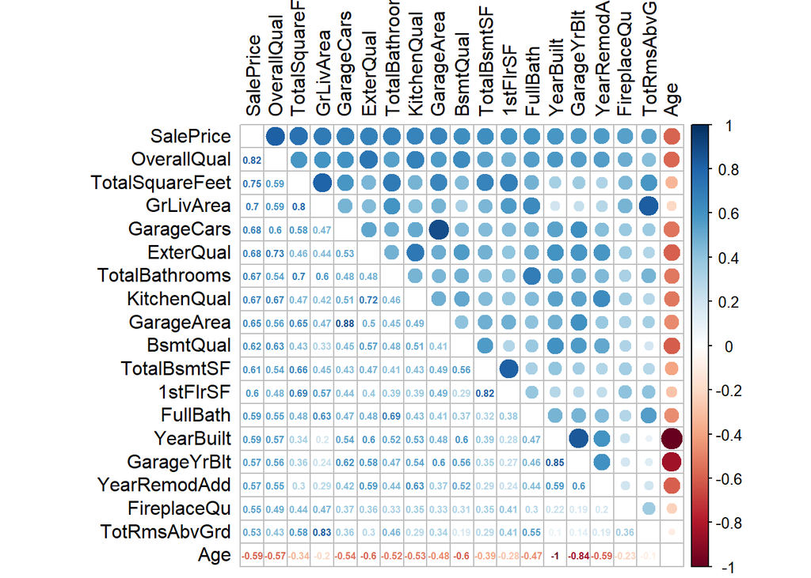

From the correlation matrix, it is clear that the multicollinearity is an issue in this analysis and dataset.

Example: GarageCars and GarageArea have a very high (88%) correlation and both have a high correlation to SalePrice. It may be a good idea to work on that later one.

If we look at the two variables that have the highest correlation to SalePrice , we have

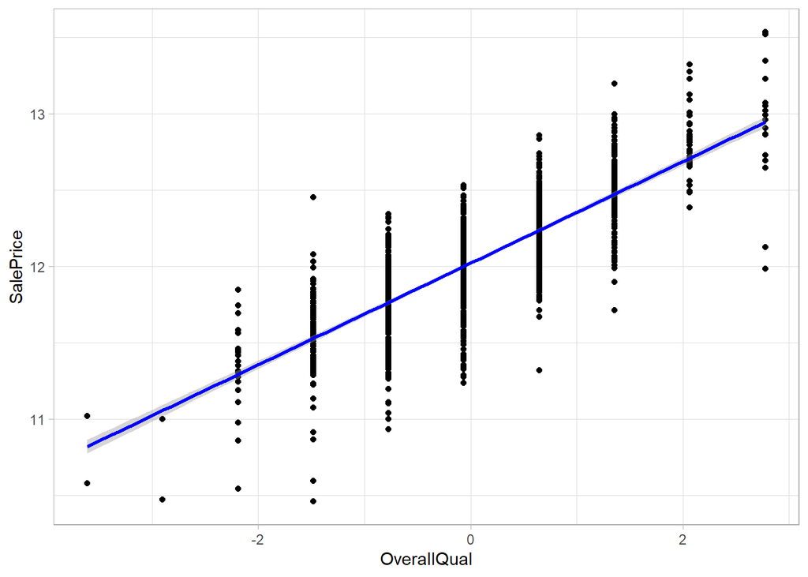

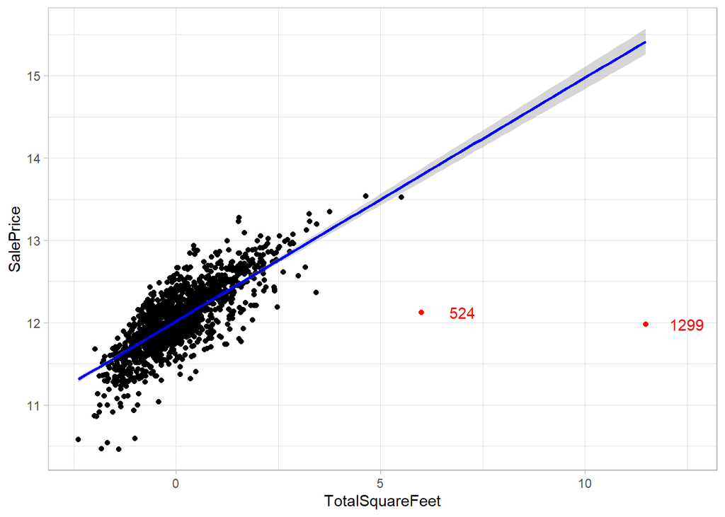

As we can see, two points with ID 524 and 1299 look quite strange: they have a very high TotalSquareFeet but low sale price.

By looking at the profiles we see that they are partial sales. But when we looked before on SaleCondition impact on SalePrice, the “Partial” value didnt seem to have a negative impact. We reserve our jugement on these 2 profiles and we may need to remove them later on.

```r
full %>%
  filter(!is.na(SalePrice)) %>%
  select_if(is.factor) %>%
  map(function(x){kruskal.test(SalePrice ~ x,
                               data = full%>% filter(!is.na(SalePrice)) )$p.value}) %>%
  as.data.frame() %>%
  pivot_longer(cols = everything(),
               names_to = "Category",
               values_to = "kruskal_pvalue") %>%
  arrange(-kruskal_pvalue) %>%
  filter(kruskal_pvalue > .02)
```

```
## # A tibble: 7 x 2
##   Category    kruskal_pvalue
##   <chr>                <dbl>
## 1 YrSold              0.801
## 2 Utilities           0.523
## 3 LandContour         0.494
## 4 MoSold              0.435
## 5 Street              0.0801
## 6 LandSlope           0.0560
## 7 Condition2          0.0551
```

Thus it may be a good idea to remove them later on, before training the model(s).

### 5.2 Variable importance with elastic net and random forest

Although the correlations and kruskal tests are giving a good overview of the most important variables (+ some first view on the multi collinearity), let’s get another overview of the most important variables, including the categorical variables, before moving on to visualization.

To do that, we check the variables importance with 2 models, to look at the top 20% of variables:

- A quick random forest model with 100 trees
- A LASSO model

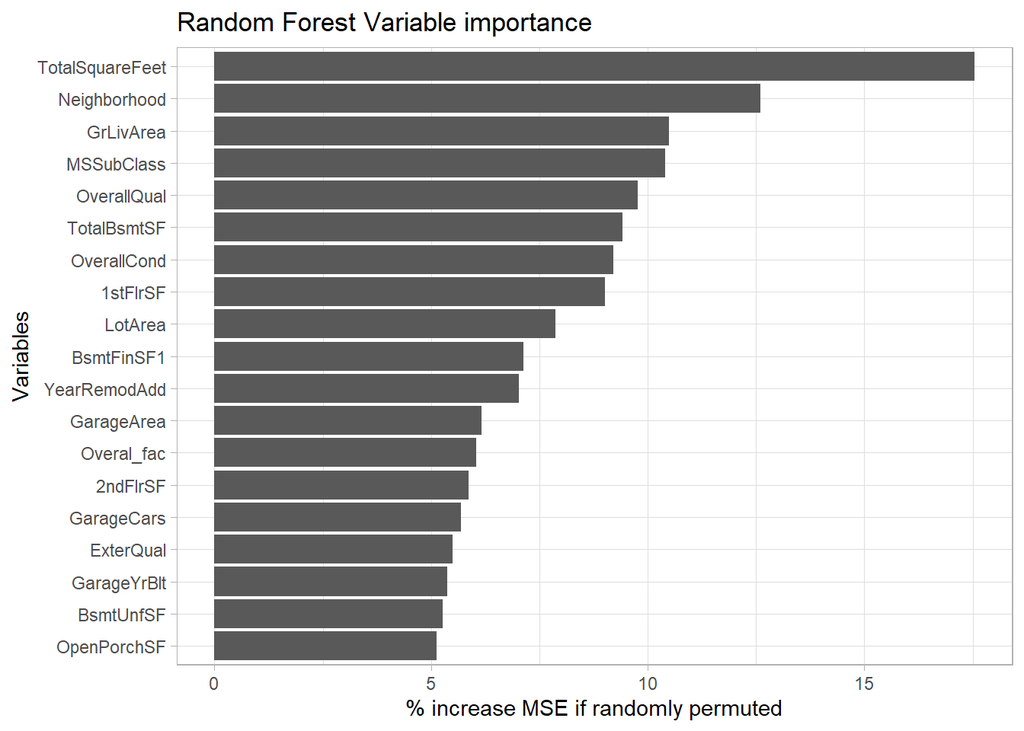

```r
set.seed(12345)
randomForest::randomForest(x=full %>%
                             filter(!is.na(SalePrice)) %>%
                             dplyr::select(- SalePrice),
                           y=full$SalePrice[!is.na(full$SalePrice)],
                           ntree=100,
                           importance=TRUE) %>%
  randomForest::importance(.) %>%
  as.data.frame() %>%
  mutate(Variables = row.names(.)) %>%
  rename(MSE = '%IncMSE') %>%
  arrange(-MSE) %>%
  filter(MSE >= quantile(.$MSE,0.8)) %>%
  ggplot(.,
         aes(x=reorder(Variables, MSE),
             y=MSE)) +
  geom_bar(stat = 'identity') +
  labs(x = 'Variables',
       y= '% increase MSE if randomly permuted') +
  coord_flip()  +
  theme(legend.position="none",
        plot.title = element_text(hjust = 0.5)) +
  ggtitle("Random Forest Variable importance") +
  theme_light()
```

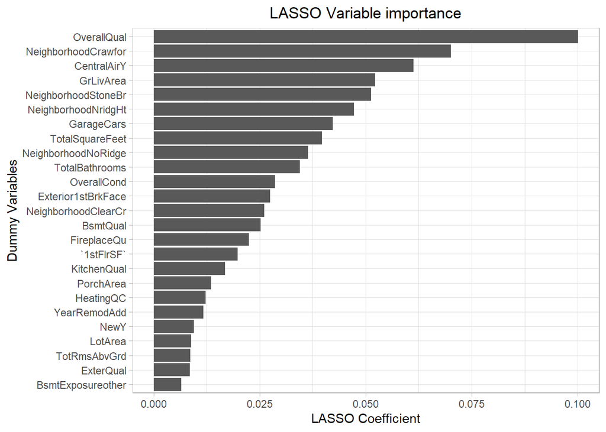

```r
x_vars <- model.matrix(SalePrice~. , full %>%
                         filter(!is.na(SalePrice)))[,-1]
y_var <- full$SalePrice[!is.na(full$SalePrice)]
lambda_seq <- 10^seq(2, -2, by = -.1)
set.seed(12345)
cv_output <- glmnet::cv.glmnet(x_vars,
                               y_var,
                               alpha = 1,
                               lambda = lambda_seq,
                               nfolds = 10)
set.seed(12345)
glmnet::glmnet(x_vars,
               y_var,
               alpha=1,
               lambda = cv_output$lambda.min) %>%
  coef() %>%
  as.matrix() %>%
  data.frame() %>%
  mutate(Variables = row.names(.)) %>%
  rename(coeff = s0) %>%
  arrange(-coeff) %>%
  filter(abs(coeff) >= quantile(abs(.$coeff),0.8),
         coeff > 0,
         Variables != "(Intercept)") %>%
  ggplot(.,
         aes(x=reorder(Variables, coeff),
             y=coeff)) +
  geom_bar(stat = 'identity') +
  labs(x = 'Dummy Variables',
       y= 'LASSO Coefficient') +
  coord_flip() +
  theme_light() +
  theme(legend.position="none",
        plot.title = element_text(hjust = 0.5)) +
  ggtitle("LASSO Variable importance")
```

## Step 6: Removing dataset

### 6.1 binned variables created in step 4

When looking at the number of bathrooms in the house, we see that the TotalBathrooms variable has a higher correlation to SalePrice than each of its components. The next one would have been FullBath, but it is highly correlated to TotalBathrooms. The other 3 are lowly correlated to SalePrice. We remove all of them and keep only TotalBathrooms.

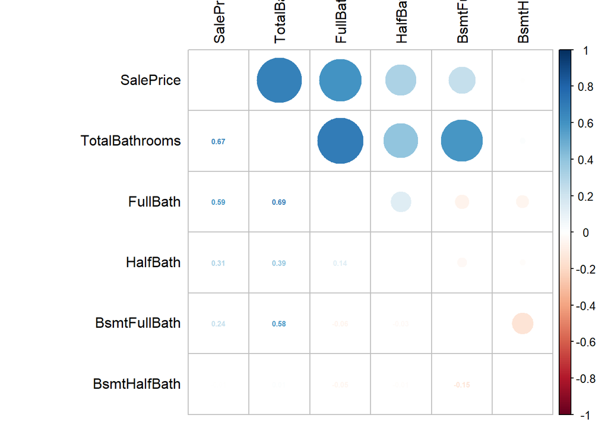

As for the different numerical variables related to Age, we can see that Age and YearBuilt are perfectly correlated, which makes a lot of sense. We are removing YearBuilt and YearRemodAdd from the dataset.

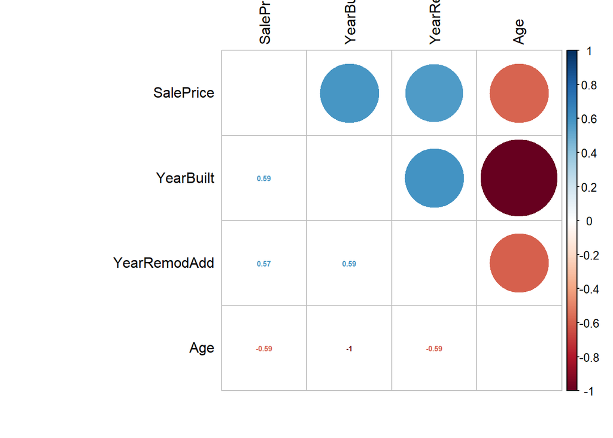

Concerning the numerical variables related to living or Porch Area, we see that the new variables created (PorchArea and TotalSquareFeet) are more correlated to SalePrice than each of their components. We will remove the components from the training dataset.

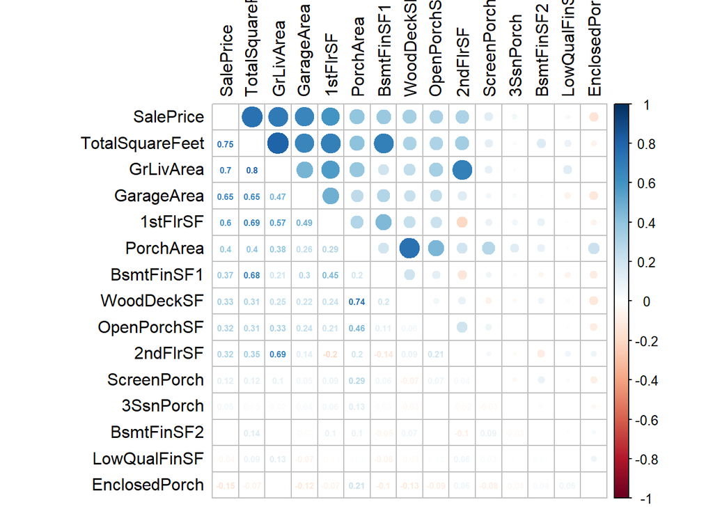

### 6.2 highly correlated variables

As seen above, we have a lot of highly correlated variables in the dataset. We will look at the variables that are highly correlated to each other and remove the one which has the lowest correlation to Sale Price. If we look at the first 20 highly correlated variables we have the following:

```
## # A tibble: 20 x 3
##    base            correlated_to  correlation
##    <chr>           <chr>                <dbl>
##  1 GarageCond      GarageQual           0.959
##  2 PoolQC          PoolArea             0.937
##  3 FireplaceQu     Fireplaces           0.863
##  4 ExterQual       OverallQual          0.726
##  5 KitchenQual     ExterQual            0.716
##  6 TotalSquareFeet TotalBathrooms       0.704
##  7 TotRmsAbvGrd    BedroomAbvGr         0.677
##  8 KitchenQual     OverallQual          0.673
##  9 TotalSquareFeet TotalBsmtSF          0.661
## 10 BsmtCond        BsmtQual             0.634
## 11 BsmtQual        OverallQual          0.629
## 12 GarageCars      GarageYrBlt          0.620
## 13 GarageCars      OverallQual          0.601
## 14 TotalSquareFeet OverallQual          0.588
## 15 TotalSquareFeet TotRmsAbvGrd         0.584
## 16 GarageYrBlt     ExterQual            0.583
## 17 TotalSquareFeet GarageCars           0.583
## 18 GarageQual      GarageCars           0.577
## 19 GarageCond      GarageCars           0.568
## 20 BsmtQual        ExterQual            0.566
```

We can see that many variables on the same topic, like Garage or Basement, are highly correlated, which makes a lot of sense. When we look at these variables’ correlation to SalePrice, we have the following:

```
## # A tibble: 18 x 3
##    base            correlated_to correlation
##    <chr>           <chr>               <dbl>
##  1 SalePrice       OverallQual        0.817
##  2 TotalSquareFeet SalePrice          0.749
##  3 SalePrice       GarageCars         0.681
##  4 SalePrice       ExterQual          0.679
##  5 TotalBathrooms  SalePrice          0.673
##  6 SalePrice       KitchenQual        0.668
##  7 SalePrice       BsmtQual           0.616
##  8 SalePrice       TotalBsmtSF        0.612
##  9 SalePrice       GarageYrBlt        0.569
## 10 SalePrice       FireplaceQu        0.546
## 11 SalePrice       TotRmsAbvGrd       0.534
## 12 SalePrice       Fireplaces         0.489
## 13 SalePrice       GarageQual         0.363
## 14 SalePrice       GarageCond         0.357
## 15 SalePrice       BsmtCond           0.275
## 16 SalePrice       BedroomAbvGr       0.209
## 17 SalePrice       PoolQC             0.0773
## 18 SalePrice       PoolArea           0.0698
```

We remove these variables which have high correlation with other variables and low(er) correlation with SalePrice.

### 6.2 outliers

We sawe earlier that 2 rows seem to have very high values for the total square feet while the sale price stays not very high. Let’s check these rows:

```r
full[c(524,1299),] %>% as.data.frame()
```

```
##           Id MSSubClass MSZoning LotFrontage  LotArea Street Alley LotShape
## 1 -1.1106008         60       RL    2.748344 3.794332   Pave    No      IR1
## 2 -0.1910328         60       RL   11.059132 6.811070   Pave    No    other
##   LandContour Utilities LotConfig LandSlope Neighborhood Condition1 Condition2
## 1       other    AllPub    Inside       Gtl      Edwards      other      other
## 2       other    AllPub    Corner       Gtl      Edwards      other       Norm
##   BldgType HouseStyle OverallQual OverallCond RoofStyle RoofMatl Exterior1st
## 1     1Fam     2Story    2.773812  -0.5071973       Hip  CompShg     CemntBd
## 2     1Fam     2Story    2.773812  -0.5071973       Hip    other      Stucco
##   Exterior2nd MasVnrType MasVnrArea  ExterCond Foundation BsmtQual BsmtExposure
## 1     CmentBd      other   3.693526 -0.2300074      PConc 1.681421        other
## 2      Stucco      other   3.883624 -0.2300074      PConc 1.681421        other
##   BsmtFinType1 BsmtFinType2  BsmtUnfSF Heating HeatingQC CentralAir Electrical
## 1          GLQ          Unf  0.7220805    GasA 0.8854676          Y      SBrkr
## 2          GLQ          Unf -0.2151546    GasA 0.8854676          Y      SBrkr
##   KitchenAbvGr TotRmsAbvGrd Functional FireplaceQu GarageType GarageFinish
## 1   -0.2076629     2.898264        Typ    1.235417      other          Fin
## 2   -0.2076629     3.535459        Typ    1.235417     Attchd          Fin
##   GarageCars GarageQual PavedDrive      PoolQC Fence MiscFeature     MiscVal
## 1  1.6189865  0.2780431          Y -0.06339379    No          No -0.08957661
## 2  0.3069872  0.2780431          Y 15.68524229    No          No -0.08957661
##   MoSold YrSold SaleType SaleCondition SalePrice Overal_fac TotalBathrooms
## 1  other   2007    other         other  12.12676      other       2.820833
## 2  other   2008    other         other  11.98293      other       2.820833
##         Age Remodeled New PorchArea TotalSquareFeet BinNeigh BinMSSub BinExt1
## 1 -1.202523         N   Y  2.693642        6.002779      Med     High    High
## 2 -1.202523         Y   Y  2.018733       11.481680      Med     High     Med
##   BinExt2
## 1     Med
## 2     Med
```

Both of them are new built, with good quality in general and high size. It is probably an error in the dataset.

We remove the two rows containing these profiles.

```r
full[full$TotalSquareFeet>= quantile(full$TotalSquareFeet,0.999),]%>% as.data.frame()
```

```
##           Id MSSubClass MSZoning LotFrontage  LotArea Street Alley LotShape
## 1 -1.1106008         60       RL    2.748344 3.794332   Pave    No      IR1
## 2 -0.1910328         60       RL   11.059132 6.811070   Pave    No    other
## 3  1.2933279         20       RL    2.657516 3.692392   Pave    No      IR1
##   LandContour Utilities LotConfig LandSlope Neighborhood Condition1 Condition2
## 1       other    AllPub    Inside       Gtl      Edwards      other      other
## 2       other    AllPub    Corner       Gtl      Edwards      other       Norm
## 3       other    AllPub    Inside       Gtl      Edwards       Norm       Norm
##   BldgType HouseStyle OverallQual OverallCond RoofStyle RoofMatl Exterior1st
## 1     1Fam     2Story    2.773812  -0.5071973       Hip  CompShg     CemntBd
## 2     1Fam     2Story    2.773812  -0.5071973       Hip    other      Stucco
## 3     1Fam     1Story    2.773812  -0.5071973       Hip  CompShg     CemntBd
##   Exterior2nd MasVnrType MasVnrArea  ExterCond Foundation BsmtQual BsmtExposure
## 1     CmentBd      other   3.693526 -0.2300074      PConc 1.681421        other
## 2      Stucco      other   3.883624 -0.2300074      PConc 1.681421        other
```

[output cut: 25 more lines]

### 6.3 Near- zero variance

```r
full %>%
  select_if(is.factor) %>%
  caret::nearZeroVar(.,
                     saveMetrics = TRUE) %>%
  rownames_to_column() %>%
  # filter(nzv) %>%
  arrange(-freqRatio)
```

```
##          rowname   freqRatio percentUnique zeroVar   nzv
## 1      Utilities 2918.000000    0.06851662   FALSE  TRUE
## 2         Street  242.250000    0.06851662   FALSE  TRUE
## 3     Condition2   96.300000    0.06851662   FALSE  TRUE
## 4       RoofMatl   66.883721    0.06851662   FALSE  TRUE
## 5        Heating   63.866667    0.06851662   FALSE  TRUE
## 6    MiscFeature   26.800000    0.06851662   FALSE  TRUE
## 7      LandSlope   19.702128    0.06851662   FALSE  TRUE
## 8     CentralAir   13.892857    0.06851662   FALSE FALSE
## 9          Alley   13.742424    0.06851662   FALSE FALSE
## 10    Functional   13.595000    0.06851662   FALSE FALSE
## 11    Electrical   10.817814    0.06851662   FALSE FALSE
## 12    PavedDrive    9.500000    0.06851662   FALSE FALSE
## 13   LandContour    8.828283    0.06851662   FALSE FALSE
## 14      BinNeigh    8.579861    0.10277492   FALSE FALSE
```

[output cut: 29 more lines]

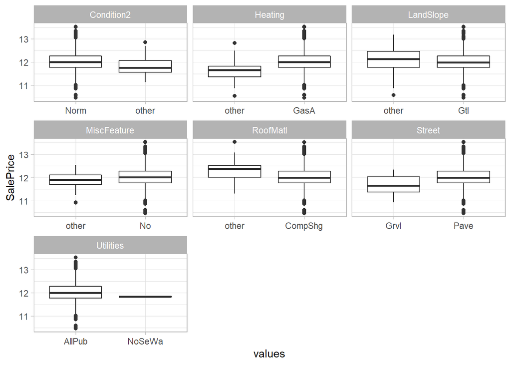

We are removing the 3 worst variables: Utilities, Street, and Condition2.

# Step 7 Dummy variables

Finally, before creating any model, we transform all the categorical into dummy variables. And remove the Id column as it won’t be necessary.

Here is the summary of the final training dataset:

```r
summary(full)
```

```
##   LotFrontage           LotArea           OverallQual
##  Min.   :-2.201797   Min.   :-1.124397   Min.   :-3.609406
##  1st Qu.:-0.430646   1st Qu.:-0.341463   1st Qu.:-0.772420
##  Median :-0.021918   Median :-0.090924   Median :-0.063174
##  Mean   :-0.005646   Mean   :-0.004903   Mean   :-0.002854
##  3rd Qu.: 0.477637   3rd Qu.: 0.175971   3rd Qu.: 0.646073
##  Max.   :11.059132   Max.   :26.001899   Max.   : 2.773812
##
##   OverallCond          MasVnrArea          ExterCond            BsmtQual
##  Min.   :-4.100666   Min.   :-0.566919   Min.   :-5.601140   Min.   :-3.84071
##  1st Qu.:-0.507197   1st Qu.:-0.566919   1st Qu.:-0.230007   1st Qu.:-0.52743
##  Median :-0.507197   Median :-0.566919   Median :-0.230007   Median : 0.57700
##  Mean   : 0.000522   Mean   :-0.004751   Mean   : 0.000237   Mean   :-0.00173
##  3rd Qu.: 0.391170   3rd Qu.: 0.340243   3rd Qu.:-0.230007   3rd Qu.: 0.57700
##  Max.   : 3.086271   Max.   : 8.378896   Max.   : 5.141125   Max.   : 1.68142
##
##    BsmtUnfSF           HeatingQC          KitchenAbvGr
##  Min.   :-1.275231   Min.   :-3.290106   Min.   :-4.870494
##  1st Qu.:-0.774766   1st Qu.:-1.202319   1st Qu.:-0.207663
##  Median :-0.212880   Median : 0.885468   Median :-0.207663
##  Mean   :-0.000583   Mean   :-0.000911   Mean   : 0.000214
##  3rd Qu.: 0.552036   3rd Qu.: 0.885468   3rd Qu.:-0.207663
##  Max.   : 4.038801   Max.   : 0.885468   Max.   : 9.117998
##
##   TotRmsAbvGrd        FireplaceQu          GarageCars
##  Min.   :-2.836488   Min.   :-0.978663   Min.   :-2.317011
##  1st Qu.:-0.924904   1st Qu.:-0.978663   1st Qu.:-1.005012
##  Median :-0.287709   Median :-0.425143   Median : 0.306987
##  Mean   :-0.004074   Mean   :-0.001271   Mean   :-0.001216
##  3rd Qu.: 0.349486   3rd Qu.: 1.235417   3rd Qu.: 0.306987
##  Max.   : 4.809848   Max.   : 1.788937   Max.   : 4.242985
##
##    GarageQual            PoolQC             MiscVal           SalePrice
##  Min.   :-3.912704   Min.   :-0.063394   Min.   :-0.08958   Min.   :10.46
##  1st Qu.: 0.278043   1st Qu.:-0.063394   1st Qu.:-0.08958   1st Qu.:11.77
##  Median : 0.278043   Median :-0.063394   Median :-0.08958   Median :12.00
##  Mean   :-0.000286   Mean   :-0.005336   Mean   :-0.01018   Mean   :12.02
##  3rd Qu.: 0.278043   3rd Qu.:-0.063394   3rd Qu.:-0.08958   3rd Qu.:12.27
##  Max.   : 3.071874   Max.   :19.622401   Max.   :27.22791   Max.   :13.53
##                                                             NA's   :1458
```

[output cut: 345 more lines]

```
##  Min.   :0.0000   Min.   :0.0000   Min.   :0.0000   Min.   :0.0000
##  1st Qu.:0.0000   1st Qu.:0.0000   1st Qu.:0.0000   1st Qu.:1.0000
##  Median :0.0000   Median :0.0000   Median :1.0000   Median :1.0000
##  Mean   :0.1433   Mean   :0.4654   Mean   :0.5346   Mean   :0.8861
##  3rd Qu.:0.0000   3rd Qu.:1.0000   3rd Qu.:1.0000   3rd Qu.:1.0000
##  Max.   :1.0000   Max.   :1.0000   Max.   :1.0000   Max.   :1.0000
##
##      New_Y
##  Min.   :0.0000
##  1st Qu.:0.0000
##  Median :0.0000
##  Mean   :0.1139
##  3rd Qu.:0.0000
##  Max.   :1.0000
##
```

# Step 8 Ideas of improvement:

There are many things that we could have done for the pre-processing of our datasets:

- We could use step_spatialsign instead of removing the 2 rows of outliers.
- We could use the step_nzv function instead of how it was done. We didnt, here, because it seems that it was removing good columns.
- We could do a PCA step to remove the multicolinearity instead of just removing columns.
- We could log transform the numerical predictors that are skewed by checking their skewness